**PROBABILITY THEORY AND INTRODUCTORY STATISTICS**  
SWAPNESH TIWARI  
ANALYZING LIZARD METRICS  
Date : 14 October, 2022

**INTRO**

**Data set Description:**

This data set is an XLSX (Microsoft Excel file) which contains three variables one about one categorical variable: Sex of the lizard, and another two about the numerical length of the lizard and heart rate of the lizard. The length of the Lizard is described as centimeters. This data set was designed in June 2022. This data set consists of a total of 120 observations.  
Body metrics are an important aspect when we talk about the blood supply of any living creature, therefore in this data set, we will analyze the length and the heart rate since the heart rate and cardiac output of a lizard are directly proportional to the length of the lizard, Meiri, S. (2010).

**Hypothesis Testing in Medical Industry:**

Hypothesis is something which is based on the educated guess or in simple words assumptions about the population. The first ever hypothesis testing was done and invented by Karl Pearson in 1857; a scientist from London, He invented this test to be used in variety of different fields such as in the field of Biology, Economics and Psychology, Magnello, M. E. (2005). In the above mentioned study by Pearson, K. published in 1922 states that when we take substantial amount of observations, we do not have any technique through which we can find the mean of population 1 and population 2 therefore to make this possible he invented hypothesis testing which is generally getting predictions for the outcome according to statistical data. According to a famous book written by Bluman, A.G published in 2009 defined Hypothesis in two terms:

1. Null Hypothesis: Bluman defines Null Hypothesis as a statistical hypothesis that shows zero difference between the two distinct population groups, the null hypothesis is denoted by H0.
2. Alternative Hypothesis: Bluman defines an alternative hypothesis as another term that states that there is a significant level of difference between the two population groups, basically it is an element that helps in rejecting the null hypothesis.

Let’s take an example for Hypothesis,

A statistician wants to know the mean heart rate of the lizards therefore the Hypothesis here will be:  
H0: U = 1.68  
H1: U = =/= 1.68

Therefore, the hypothesis states that: Null Hypothesis: mean of the lizard’s heart rate is 1.68 and will not change, whereas Alternative Hypothesis: tell the lizard’s heart rate is not equal to 1.68 or is more or less than 1.68.

In the medical industry, hypothesis testing is one of the important aspects in all fields, the most important of hypothesis testing is to plan, implement and get the desired outcome. The medical industry always experiments on two groups, one is the control group and another one is the focus group, these two groups define the result of every clinical trial, therefore to test the difference between a control and a focus group hypothesis testing is used. Let’s take an example: The statement of the problem here is to see whether vaccination against Covid - 19 is effective in decreasing the severity of Covid - 19 symptoms. So, our hypothesis here is Vaccination against Covid -19 helps in reducing the severity of Covid - 19 but on the other hand, the null hypothesis does not see any difference, it states that vaccination and Covid - 19 are independent of each other. AS we saw the examples now, we know that the null hypothesis and alternative hypothesis both are opposite to each other and the only reason we do hypothesis testing is to reject the null hypothesis.

**Z-test, T-Test and F-Test in comparing two population parameters:**

According to Bluman, A.G published book in 2009 which describes different test required to find statistical differences between the two population parameters,

1. Z-Test: According to Bluman In hypothesis testing we need to calculate the z value, which can be only be used whenever the mean of the two population parameters is equal between the two population.

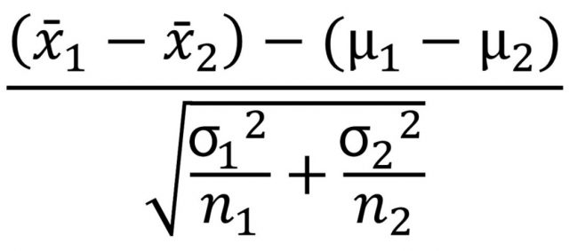

The above figure 1 shows the formula for the Z-Test to calculate difference between two population parameter.

2. T-Test: According to Bluman, T-test is used most commonly when the variables used in the test are independent of each other, and another will be when we don’t know the mean of the whole population and if they are equal between each other, using two variables, one variable describes the group and other measures the interest.

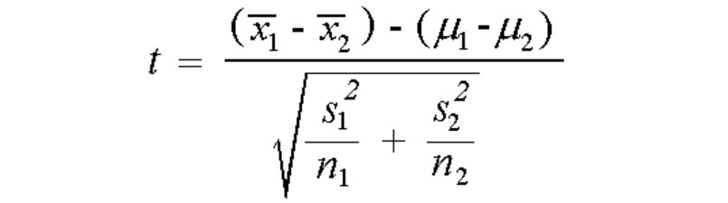

The above figure 2 shows the formula for the T-Test to calculate difference between two population parameter.

3. F-Test: According to study by R.A. Fisher published in 1928 defined F test as the ratio between the two variances which is V1 and other is V2 which is also described in a similar study by Duncan, D. B. published in 1955, states that if null hypothesis which is denoted by H0 defines mean and variance to be zero therefore the F statistics would be equal to one, Duncan also stated that F-test is based on two theoretical explanation: all the samples should have normal distribution and samples should be completely independent of each other. If these conditions are met than null hypothesis cannot be rejected and therefore the data has a distribution called as F distribution.

**Importance of referencing in paper**  
Academic referencing and citing every content is an important aspect of student integrity, as a data scientist it is important to be well oriented with citing resources since the use of articles and other academic resources is of great importance and is needed t make papers more credible and worthy since improper citations can reduce the overall quality of the paper published, Santini, A. (2018).  
Improper citing in the medical industry can also end up in difficult consequences, which can also result in legal action against the author who was charged with that guilt, in the biomedical industry it is important to maintain an integrity level, so that papers that are published are of high quality and without errors, since once the grant is denied due to negligence in the citation, that particular company cannot apply for a grant again, it will cost the company its resources, money and time, Masic, I. (2013).

```r
# Library Used in this project

library(readxl)
library(dplyr)
library(magrittr)
library(knitr)
library(kableExtra)
library(ggplot2)
library(RColorBrewer)
library(DT)

#Data source

LizardsSet = read_excel("C://Users//User//OneDrive//Documents//ALY_6010//Datasets//lizards_project4.xlsx")
```

**ANALYSIS OF DATA**

**Exercise 1, Descriptive Statistics Of Lizard Dataset**

**In this exercise I will be displaying some of the descriptive statistics from our current data set**

```r
# Generating objects
Length = LizardsSet$Length
HR = LizardsSet$HeartRate
Gender = LizardsSet$Sex

#1. stats description
MeanL = mean(Length)
MeanHR = mean(HR)

#Standard Deviation
SDL = sd(Length)
SDHR = sd(HR)

#Median
MedianL = median(Length)
MedianHR =  median(HR)

#Variance
VarL = var(Length)
VarHR = var(HR)

#Maximum Value
MaxHR = max(HR)
MaxL = max(Length)

#Minimum Value
MinL = min(Length)
MinHR = min(HR)

#Range
RangeL  = MaxL  - MinL
RangeHR = MaxHR - MinHR

#Creating object
VectorL = c(MeanL,MedianL,SDL,VarL,MinL,MaxL,RangeL)
VectorHR = c(MeanHR,MedianHR,SDHR,VarHR,MinHR,MaxHR,RangeHR)

MainVec = c(VectorL,VectorHR)

#Creating Matrix and table
Matrix1 = matrix(MainVec,nrow = 2, byrow = TRUE)
Variables = c("Mean", "Median","SD","Variance","Min value","Max Value", "Range")
Values = c("Length of Lizard","Heart rate of Lizard")

colnames(Matrix1) = Variables
rownames(Matrix1) = Values

knitr::kable(Matrix1, caption = "Descriptive Statistics of Lizards Dataset") %>%
  kableExtra::kable_styling(bootstrap_options = "striped", "Hover")
```

Descriptive Statistics of Lizards Dataset

|  | Mean | Median | SD | Variance | Min value | Max Value | Range |
| --- | --- | --- | --- | --- | --- | --- | --- |
| Length of Lizard | 21.193494 | 21.147571 | 1.4636495 | 2.1422700 | 17.589196 | 24.59921 | 7.010017 |
| Heart rate of Lizard | 2.619981 | 2.605194 | 0.5489679 | 0.3013658 | 1.072181 | 3.81009 | 2.737908 |

**Above table shows the descriptive statistics which shows the measures of central tendency, measures of dispersion.The data set consist of values from `17.5891957` to `24.5992123` related to the variable Length of Lizard and regarding the heart rate the minimum values is `1.0721814` to `3.8100897`, since our standard deviation and variance of both the variables is very low it signifies that the data is closely clustered around the mean value therefore decreasing the width and increasing the reliability of the data.**

**EXERCISE : 2, Testing differences between males and female lizard length in cm**

We know the variance of the two populations, now in this task we will be using that variance and will apply a Z-test formula which is shown in the above description.  
Hypothesis can be defined as follows:  
H0 : mean of the population 1 = mean of population 2  
H1 : mean of the population 1 =/= mean of population 2

```r
#Declaring Values for Confidence interval, if confidence interval is 99% then there is 1% significance level which is 0.01 which is called as Alpha.

ConfInterval = (0.99)
Alpha2 = 0.01


#Observations:
MaleObservations = 60
FemaleObservations = 60
#Degrees of Freedom
DF2 = MaleObservations - 1


#To get specific subset from the excel file we will use the code below:
Male = subset(LizardsSet, subset = (LizardsSet$Sex=="MALE"))
Female = subset(LizardsSet, subset = (LizardsSet$Sex=="FEMALE"))

#To calculate the measures of central tendency.
MeanLMale = round(mean(Male$Length,na.rm = T),2)
MeanLFemale  = round(mean(Female$Length,na.rm =  T),2)


#Calculating measures of Dispersion which is Standard Deviation.
MaleLengthSD = round(sd(Male$Length),2)
FemaleLengthSD = round(sd(Female$Length),2)

#We already know the variance therefore
MaleVar = 1.34
FemaleVar = 1.18

#Calculate the Z-Test
ZTestValue22 = (MeanLMale - MeanLFemale)-(0) / sqrt((MaleVar/MaleObservations) +(FemaleVar/FemaleObservations))


#Concluding hypothesis by comparing Test value to critical value(Critical Value Approach)
DF = MaleObservations - 1
CriticalValueR = round(qnorm(Alpha2/2,lower.tail = F),3)
Hypothesis1 = ifelse(ZTestValue22 > CriticalValueR,"Reject H0","Fail To Reject H0")


#P-Value Approach for T - Test
PValueStats =  pnorm(ZTestValue22, lower.tail = F) #For right tail Test
PValue = 2*(PValueStats)

Hypothesis2 = ifelse(PValue > Alpha2 ,"Fail To Reject H0","Reject H0")


#Table for Values

VectorL2 = c(MeanLMale,MeanLFemale,MaleVar,FemaleVar,ZTestValue22,DF,CriticalValueR,PValue )
MainVec2 = c(VectorL2)
Matrix2 = matrix(MainVec2,nrow = 8,ncol = 1, byrow = TRUE)
Variables2 = c("Mean Length of Males", "Mean Length of Females","Variance in Length of Males","Variance in Length of Females","Z-Test Value","Degrees of Freedom", "Critical Value of T on the right", "P- Value")
Values2 = c("Values")

colnames(Matrix2) = Values2
rownames(Matrix2) = Variables2

DT::datatable(Matrix2, caption = "Testing differences between males and female lizard length in cm ")
```

|  | Values |
| --- | --- |
| Mean Length of Males | 22.24 |
| Mean Length of Females | 20.15 |
| Variance in Length of Males | 1.34 |
| Variance in Length of Females | 1.18 |
| Z-Test Value | 2.09 |
| Degrees of Freedom | 59 |
| Critical Value of T on the right | 2.576 |
| P- Value | 0.0366177997033179 |

```r
#Table for Hypothesis
object2 = c(Hypothesis1, Hypothesis2)
HypoTable2   = matrix(object2 , nrow=2,ncol = 1,  byrow = TRUE)
Values2   = c("Hypothesis")
Rows1 = c("Z-TestValue > CriticalValueR", "PValue > Alpha2")
row.names(HypoTable2) = Rows1
colnames(HypoTable2)  = Values2

knitr::kable(HypoTable2) %>%
  kableExtra::kable_paper(full_width = F)
```

|  | Hypothesis |
| --- | --- |
| Z-TestValue > CriticalValueR | Fail To Reject H0 |
| PValue > Alpha2 | Fail To Reject H0 |

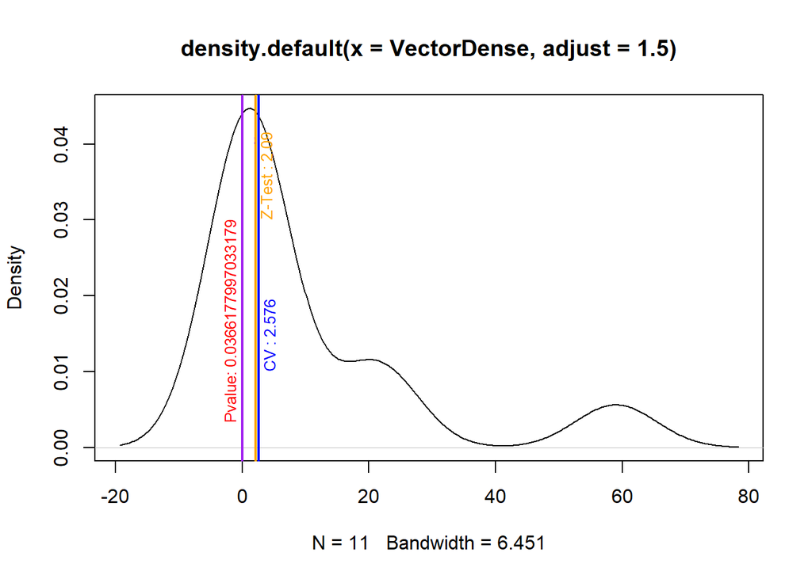

```r
#Density plot

VectorDense = c(MeanLMale,MeanLFemale,MaleVar,FemaleVar,MaleLengthSD,FemaleLengthSD , ZTestValue22,DF,CriticalValueR,PValue, Alpha2)
density(VectorDense, adjust = 1.5) %>%
  plot()

abline(v=PValue, col = "Red", lwd = 2)
abline(v=Alpha2, col = "purple", lwd = 2)
abline(v=CriticalValueR, col = "Blue", lwd = 2)
abline(v=ZTestValue22, col = "Orange", lwd = 2)

text(x = PValue,
     paste("Pvalue:", PValue ),
     y = 0.03,
     col = "Red",
     cex = 0.8,
     srt = 90,
     pos = 2)

text(x = Alpha2,
     paste("Alpha :", Alpha2 ),
     y = 0.04,
     col = "purple",
     cex = 0.020,
     srt = 90,
     pos = 4)

text(x = CriticalValueR,
     paste("CV :", CriticalValueR ),
     y = 0.01,
     col = "blue",
     cex = 0.8,
     srt = 90,
     pos = 4)


text(x = ZTestValue22,
     paste("Z-Test :", ZTestValue22 ),
     y = 0.030,
     col = "orange",
     cex = 0.8,
     srt = 90,
     pos = 4)
```

In the above task to display results I have generated three visualization, two tables and one density plot. In the density plot it is easy to visualize the difference between the P value which is `0.0366178`, Critical Value to the right which is `2.576`, and Alpha value which is `0.01`, now interpreting this values: as seen in the density plot P-Value is denoted in red which is greater than alpha which is denoted by purple line, shows that we cannot reject null hypothesis and Z-Test value which is lesser than Critical Value again denotes that we failed to reject null hypothesis therefore  
1. According to Critical Value Approach Male and female lizards have the same length  
2. According to P-value approach Male and Female lizards have the same length  
Therefore we do not have enough evidence to reject null hypothesis.

**Exercise : 3, Comparing length of two populations**

In this exercise I will be comparing the length of the two population that is male and female lizards, before we will calculate the variances of both the population.

```r
Alpha3 = 0.01
VarianceMale3 = var(Male$Length)
VarianceFemale3 = var(Female$Length)

#According to Bluman an F test is used when we need to compare the variances and standard deviations between the two sets of population, therefore here we need to compare whether the variance of length of the female lizards is higher than that of the males.

FTest = VarianceMale3/VarianceFemale3

#According to the table which contains F distribution values the critical value was calculated according to the Degrees of freedom in the denominator section and in the numerator section.Bluman, A. G. (2009), Therefore:

CriticalValue3 = 1.84

#Or we can also use R to calculate the F critical value

DF_3_M = MaleObservations - 1
DF_3_F = FemaleObservations - 1

FCriticalValue3 = round(qf(0.01, DF_3_M, DF_3_F,lower.tail=F),3)

#Now comparing the F-Test with the Critical value we need to state the hypothesis:

Hypothesis3 = ifelse(FTest > FCriticalValue3, "Reject H0" ,"Fail To Reject H0")


PValueStats33 =  pnorm(FTest, lower.tail = F) #For right tail Test
PValue3 = 2*(PValueStats33)

#Table for Values

VectorF1 = c(VarianceMale3, VarianceFemale3, FTest, FCriticalValue3, PValue3)
MainVecF1 = c(VectorF1)
MatrixF1 = matrix(MainVecF1,nrow = 5,ncol = 1, byrow = TRUE)
VariablesF1 = c("Variance of Male Population", "Variance of Female Population","Test Value of F", "Critical Value of F", "P-Value")
ValuesF1 = c("Values")

colnames(MatrixF1) = ValuesF1
rownames(MatrixF1) = VariablesF1

knitr::kable(MatrixF1, caption = "Comparing the length of the two population that is male and female ") %>%
  kableExtra::kable_styling(bootstrap_options = "striped", "Hover")
```

Comparing the length of the two population that is male and female

|  | Values |
| --- | --- |
| Variance of Male Population | 1.0052715 |
| Variance of Female Population | 1.0829687 |
| Test Value of F | 0.9282554 |
| Critical Value of F | 1.8460000 |
| P-Value | 0.3532751 |

```r
#Table for Hypothesis
object3 = c(Hypothesis3)
HypoTable3   = matrix(object3 , nrow=1,  byrow = TRUE)
Values3   = c("Hypothesis")
Rows3 = c("FTest > FCriticalValue")
row.names(HypoTable3) = Rows3
colnames(HypoTable3)  = Values3

knitr::kable(HypoTable3) %>%
  kableExtra::kable_paper(full_width = F)
```

|  | Hypothesis |
| --- | --- |
| FTest > FCriticalValue | Fail To Reject H0 |

Since we need to confirm the hypothesis we tested in the above task we need to run the numbers using the F test, F-test is not the one on which we should rely on to get the hypothesis results but P-Value approach is also necessary.Therefore according to F-test value which is `0.9282554` comparing it to the `1.846` we do not have enough evidence to reject null hypothesis. Now coming back to the question is female length variance higher than the male variance?  
So according to the data presented above we cannot reject the null hypothesis which states that there is no difference between the variance of the female and male length, therefore answer is that female length variance is same as the variance of male length.

**Exercise : 4, Hypothesis Testing Of Mean Heart Rate**

In this exercise we will be calculating values to check whether the mean heart rate of female lizards are not equal with male lizards.  
H0 : Heart rate are equal between male and female lizards  
H1 : Heart rate are not equal between male and female lizards

```r
#Declaring Values for Confidence interval, if confidence interval is 99% then there is 1% significance level which is 0.01 which is called as Alpha.

ConfInterval4 = (0.99)
Alpha4 = 0.01

#Observations:
MaleObservations4 = 60
FemaleObservations4 = 60
#Degrees of Freedom
DF4 = MaleObservations - 1



#First calculate the measures of central tendency.
MeanHRMale = round(mean(Male$HeartRate,na.rm = T),2)
MeanHRFemale  = round(mean(Female$HeartRate,na.rm =  T),2)


#Calculating measures of Dispersion which is Standard Deviation.
MaleHRSD = round(sd(Male$HeartRate),2)
FemaleHRSD = round(sd(Female$HeartRate),2)

#We already know the variance therefore
MaleVar4 = 0.34
FemaleVar4 = 0.3


#Calculate the Z-Test Value
ZTestValue4= round((MeanHRMale - MeanHRFemale)-(0) / sqrt((MaleVar4/MaleObservations4) +(FemaleVar4/FemaleObservations4)),2)


#Concluding hypothesis by comparing Test value to critical value(Critical Value Approach)
Hypothesis6 = ifelse(ZTestValue4 > CriticalValueR ,"Reject H0","Fail To Reject H0" )


#P-Value Approach for T - Test
PValueStats4 =  pnorm(ZTestValue4,lower.tail = F) #For right tail Test
PValue4 = (PValueStats4)
Hypothesis4 = PValue4 > Alpha4


Hypothesis7 = ifelse(PValue4 > Alpha4 ,"Fail To Reject H0", "Reject H0" )


#Table for Values

VectorHR4 = c(MeanHRMale ,MeanHRFemale ,MaleVar4,FemaleVar4,ZTestValue4,DF4,CriticalValueR,PValue4 )
MainVec4 = c(VectorHR4)
Matrix4 = matrix(MainVec4,nrow = 8,ncol = 1, byrow = TRUE)
Variables4 = c("Mean Heart Rate of Males", "Mean Heart Rate of Females","Variance in Heart Rate of Males","Variance in Heart Rate of Females(BPM)","Z-Test Value","Degrees of Freedom", "Critical Value of on the right", "P- Value")
Values4 = c("Values")

colnames(Matrix4) = Values4
rownames(Matrix4) = Variables4

knitr::kable(Matrix4, caption = "Testing differences between males and female lizard Heart rate ") %>%
  kableExtra::kable_styling(bootstrap_options = "striped", "Hover")
```

Testing differences between males and female lizard Heart rate

|  | Values |
| --- | --- |
| Mean Heart Rate of Males | 2.7000000 |
| Mean Heart Rate of Females | 2.5400000 |
| Variance in Heart Rate of Males | 0.3400000 |
| Variance in Heart Rate of Females(BPM) | 0.3000000 |
| Z-Test Value | 0.1600000 |
| Degrees of Freedom | 59.0000000 |
| Critical Value of on the right | 2.5760000 |
| P- Value | 0.4364405 |

```r
#Table for Hypothesis
object2 = c(Hypothesis6, Hypothesis7)
HypoTable2   = matrix(object2 , nrow=2,ncol = 1,  byrow = TRUE)
Values2   = c("Hypothesis")
Rows1 = c("Z-TestValue < CriticalValueR", "PValue > Alpha2")
row.names(HypoTable2) = Rows1
colnames(HypoTable2)  = Values2

knitr::kable(HypoTable2) %>%
  kableExtra::kable_paper(full_width = F)
```

|  | Hypothesis |
| --- | --- |
| Z-TestValue < CriticalValueR | Fail To Reject H0 |
| PValue > Alpha2 | Fail To Reject H0 |

Hence we can conclude that from above data we do not have enough evidence to reject null hypothesis on 99% confidence level and 0.01 significance level therefore there is no significant difference between the heart rate of male and female lizards.

**Exercise : 5, Calculating for differences between the two population in regards to heart rate of lizards**

In this Exercise we will be testing for heart rate variances in the given two populations of lizards, hypothesis stated as follows:  
H0 : No difference between variance of heart rate of two populations.  
H1 : Mean heart rate variance is higher in females

```r
Alpha3 = 0.01
VarianceMale5 = var(Male$HeartRate)
VarianceFemale5 = var(Female$HeartRate)


#According to Bluman an F test is used when we need to compare the variances and standard deviations between the two sets of population, therefore here we need to compare whether the variance of length of the female lizards is higher than that of the males.

FTest5 = VarianceFemale5/VarianceMale5 #Since we need highest value in the numerator therefore we will put Variance of Female

#According to the table which contains F distribution values the critical value was calculated according to the Degrees of freedom in the denominator section and in the numerator section.Bluman, A. G. (2009), Therefore:

CriticalValue5_1 = 1.84

#Or we can also use R to calculate the F critical value

DF_5_M = MaleObservations - 1
DF_5_F = FemaleObservations - 1

FCriticalValue5_2 = round(qf(0.01, DF_3_M, DF_3_F,lower.tail=F),3)



PValueStats55 =  pnorm(FTest5, lower.tail = F) #For right tail Test
PValue55 = 2*(PValueStats55)

#Now comparing the F-Test with the Critical value we need to state the hypothesis:

Hypothesis5 = ifelse(FTest5 > FCriticalValue5_2 ,"Fail To Reject H0", "Reject H0")
Hypothesis5_2 = ifelse(PValue55 > Alpha3 ,"Fail To Reject H0", "Reject H0" )


#Table for Values

VectorF2 = c(VarianceMale5, VarianceFemale5, FTest5, FCriticalValue5_2,PValue3)
MainVecF2 = c(VectorF2)
MatrixF2 = matrix(MainVecF2,nrow = 5,ncol = 1, byrow = TRUE)
VariablesF2 = c("Variance of Male Population", "Variance of Female Population","Test Value of F", "Critical Value of F", "P-Value")
ValuesF2 = c("Values")

colnames(MatrixF2) = ValuesF2
rownames(MatrixF2) = VariablesF2

knitr::kable(MatrixF2, caption = "Testing differences between variance of males and female lizard Heart rate ") %>%
  kableExtra::kable_styling(bootstrap_options = "striped", "Hover")
```

Testing differences between variance of males and female lizard Heart rate

|  | Values |
| --- | --- |
| Variance of Male Population | 0.2519606 |
| Variance of Female Population | 0.3439155 |
| Test Value of F | 1.3649573 |
| Critical Value of F | 1.8460000 |
| P-Value | 0.3532751 |

```r
#Table for Hypothesis
object5 = c(Hypothesis5, Hypothesis5_2)
HypoTable5   = matrix(object5 , nrow=2, ncol=1, byrow = TRUE)
Values5  = c("Hypothesis")
Rows5 = c("FTest > FCriticalValue","PValue > Alpha2")
row.names(HypoTable5) = Rows5
colnames(HypoTable5)  = Values5

knitr::kable(HypoTable5) %>%
  kableExtra::kable_paper(full_width = F)
```

|  | Hypothesis |
| --- | --- |
| FTest > FCriticalValue | Reject H0 |
| PValue > Alpha2 | Fail To Reject H0 |

**Exercise 6**

This exercise will focus on generating a hypothesis based on 2 different samples which are paired in nature, hypothesis can be defined as follows:  
H0 : there is no effect of meditation on sleep quality  
H1 : meditation has an effect on sleep quality

```r
#Datasets
Data1 = c(5.7, 7.8, 5.9, 5.6, 5.9, 6.8, 5.7, 3.9, 4.6, 4.5, 7.7, 6.3)
Data2 = c(6.8, 8.7, 7.6, 6.2, 6.1, 7.7, 5.9, 4.5, 6.5, 6.1, 6.9, 9.2)

#Observations
n   = 12
DF = n-1

Mean6_1 = round(mean(Data1),2)
Mean6_2 = round(mean(Data2,2))
SD6_1 = round(sd(Mean6_1, na.rm = T),2)
SD6_2 = round(sd(Mean6_2, na.rm = T),2)
Matrix6 = matrix(c(Data1,Data2), nrow = 12, ncol = 4, byrow = F)

DataS = as.data.frame(Matrix6)
colnames(DataS) = c("Before Workshop","After Workshop", "Diff", "Diffsqr")
DifferenceValue  = DataS %>%
  mutate(Difference = Data1 - Data2, DiffSqaure = Difference^2)

SumDiff = sum(DifferenceValue$Difference)
DifferenceBar = sum(DifferenceValue$Difference)/n
DiffSumSq = sum(DifferenceValue$DiffSquare)

DifferenceSD = sqrt((n*DiffSumSq - SumDiff^2))/(n*(DF))

TTest = DifferenceBar/(DifferenceSD/sqrt(n))

Alpha6  = 0.01

CriticalValue8  = qnorm(Alpha6/2,DF)

Hypothesis9 = ifelse(TTest > CriticalValue8 ,"Fail To Reject H0", "Reject H0")

TableSleep = matrix(c(Data1,Data2), ncol = 4, byrow = F)
colnames(DataS)  = c("Before Workshop","After Workshop", "Difference", "Square of Difference" )
FinalTable6  = knitr::kable(DataS, caption = "This table shows calculated difference values before and after meditation workshop") %>%
  kableExtra::kable_classic_2()
FinalTable6
```

| Before Workshop | After Workshop | Difference | Square of Difference |
| --- | --- | --- | --- |
| 5.7 | 6.8 | 5.7 | 6.8 |
| 7.8 | 8.7 | 7.8 | 8.7 |
| 5.9 | 7.6 | 5.9 | 7.6 |
| 5.6 | 6.2 | 5.6 | 6.2 |
| 5.9 | 6.1 | 5.9 | 6.1 |
| 6.8 | 7.7 | 6.8 | 7.7 |
| 5.7 | 5.9 | 5.7 | 5.9 |
| 3.9 | 4.5 | 3.9 | 4.5 |
| 4.6 | 6.5 | 4.6 | 6.5 |
| 4.5 | 6.1 | 4.5 | 6.1 |
| 7.7 | 6.9 | 7.7 | 6.9 |
| 6.3 | 9.2 | 6.3 | 9.2 |

```r
#Calculating for Difference

Difference1 = (Data1)-(Data2) #differences of the values
SumDiff2 = sum(Difference1^2)
MeanDiff = sum(Difference1)/n #Mean of the differences
DiffSD = sqrt((n*SumDiff2)-(SumDiff2))/sqrt (n*(DF))#the standard deviation of differences

#Calculating Test Value
StandError = DiffSD/sqrt(n) #Standard Error of differences
TestValue6 = MeanDiff-0/DiffSD/sqrt(n) #Test Value

#CV value retrieved from the table provided in Bluman, A. G. (2009).
CV6 = -2.718 #SInce our test value is negative
Hypothesis10 = ifelse(TestValue6<CV6,"Reject H0","Fail To Reject H0" )



#Creating object to store multiple objects

PopObjects = c(Difference1,SumDiff2,MeanDiff,DiffSD,StandError,TestValue6)
PopNames = c("Difference","Difference of the sum","Mean Difference", "Standard Deviation Difference","Standard Error","Test value of Differences")

#Creating Matrix
Matrix8 = matrix(data = c(PopNames,PopObjects),nrow = 6,ncol = 2,byrow = F)
colnames(Matrix8) =  c("Measures","Values")



#Table for Hypothesis
object6 = c(Hypothesis10)
HypoTable6   = matrix(object2 , nrow=1,ncol = 1,  byrow = TRUE)
Values6   = c("Hypothesis")
Rows6 = c("Z-TestValue < CriticalValueR")
row.names(HypoTable6) = Rows6
colnames(HypoTable6)  = Values6

knitr::kable(HypoTable6)%>%
  kableExtra::kable_classic_2()
```

|  | Hypothesis |
| --- | --- |
| Z-TestValue < CriticalValueR | Fail To Reject H0 |

```r
#task 6.3
Final6 = knitr::kable(Matrix8)%>%
  kableExtra::kable_paper()
Final6
```

| Measures | Values |
| --- | --- |
| Difference | -1.1 |
| Difference of the sum | -0.899999999999999 |
| Mean Difference | -1.7 |
| Standard Deviation Difference | -0.600000000000001 |
| Standard Error | -0.199999999999999 |
| Test value of Differences | -0.9 |

**CONCLUSION**

Considering the hypothesis testing with the above data for two differences we also need to keep in mind about the errors which can occur, such as type 1 error which means we reject a null hypothesis which is actually true about the population, whereas type 2 error results when we accept the null hypothesis which is supposed to be false in the whole population. Therefore errors should be considered seriously since in medical field it can be dangerous to develop drugs with wrong predictions. Therefore it is recommended to use a P-value approach every time for hypothesis testing to avoid any errors which can make the data invalid.

This project sharpened by skills to do hypothesis testing, it also helped me in learning new F-Test approach to define the hypothesis testing, practicing calculating different test such as Z-test, F-Test and T-test will help me in advancing in my career and will help me to increase my knowledge in analytics which will help me to make better decisions in the near future relating to the actual industrial experience.

**REFERENCES**

Bluman, A. G. (2009). Elementary statistics: A step by step approach. New York: McGraw-Hill Higher Education.

Duncan, D. B. (1955). Multiple range and multiple F tests. biometrics, 11(1), 1-42.

Fisher, R. A., & Tippett, L. H. C. (1928, April). Limiting forms of the frequency distribution of the largest or smallest member of a sample. In Mathematical proceedings of the Cambridge philosophical society (Vol. 24, No. 2, pp. 180-190). Cambridge University Press.

Kumar, A. (2015). Hypothesis testing in medical research: a key statistical application. Journal of Universal College of Medical Sciences, 3(2), 53-56.

Magnello, M. E. (2005). karl pearson, paper on the chi-square goodness of fit test (1900). In Landmark Writings in Western Mathematics 1640-1940 (pp. 724-731). Elsevier Science.

Masic, I. (2013). The importance of proper citation of references in biomedical articles. Acta Informatica Medica, 21(3), 148.

Meiri, S. (2010). Length–weight allometries in lizards. Journal of Zoology, 281(3), 218-226.

Pearson, K. (1922). On the χ 2 test of goodness of fit. Biometrika, 14(1/2), 186-191.

Santini, A. (2018). The importance of referencing. The Journal of Critical Care Medicine, 4(1), 3.

**APPENDIX**

A R File has been attached with this report named as : M4Project.rmd